# RProjects

Creating a project-oriented workflow in R

Author

Affiliation

Daniela Palleschi

Humboldt-Universität zu Berlin

Published

May 6, 2024

# Learning Objectives

Today we will…

- learn about project-oriented workflows
- create an RProject
- establish a self-contained project environment with `here`

# Installation requirements

- required installations/recent versions of:
  - R
    - version `4.4.0`, “Puppy Cup”
    - check current version with `R.version`
    - download/update: https://cran.r-project.org/bin/macosx/
  - RStudio
    - version `2023.12.1.402`, “Ocean Storm”
    - Help > Check for updates
    - new install: https://posit.co/download/rstudio-desktop/

# Project-oriented workflow

1. Folder structure:
   - keeping everything related to a project in one place
   - i.e., contained in a single folder, with subfolders as needed
2. Project-relative working directory
   - the project folder should act as your working directory
   - all file paths should be relative to this folder

## Folder structure

- a core computer literacy skill
  - keep your Desktop as empty as possible
  - have a sensible folder structure
  - avoid mixing subfolders and files
    - i.e., if a folder contains subfolders, ideally it should not contain files

# RProjects

## Creating a new Project

- when?
  - whenever you’re starting a new course or project which will use R
- why?
  - to keep all the relavent materials in one place
- where?
  - somewhere that makes sense, e.g., a folder called `SoSe2024` or `Mastersarbeit`
- how?
  - `File > New Project > New Directory > New Project > [Directory name] > Create Project`

**New RProject**

Create a new RProject for this course

- `File > New Project > New Directory > New Project > [Directory name] > Create Project`
- make sure you choose a sensible location

## Opening a Project

- to open a project, locate its `.Rproj` file and double-click
- or if you’re already in RStudio, you can use the `Project (None)` drop-down (top right)

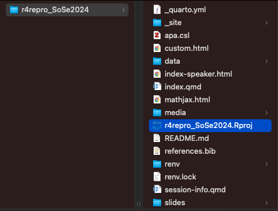

Figure 1: Double-click `.Rproj`

[figure not shown]

Figure 2: Open from RStudio

## Global RStudio options

[figure not shown]

Figure 3: RStudio settings for reproducibility

- `Tools > Global Options`
  - **Workspace**: Restore .RData into workspace at startup: NO
  - Save workspace to .RData on exit: Never
- this will ensure that you are always starting with a clean slate
  - and that your code is not dependent on some pacakge or object you created in another session
- this is also how RMarkdown and Quarto scripts run
  - they start with an empty environment and run the script linearly

**Global settings**

Change your Global Options so that

- **Workspace**: Restore .RData into workspace at startup: NO
- Save workspace to .RData on exit: Never

## Spot the differences

[figure not shown]

Figure 4: RStudio Session A

[figure not shown]

Figure 5: RStudio Session B

## Spot the differences: RProject vs. None

[figure not shown]

## Folder structure

- some folders you’ll typically want to have:
  - `data`: containing your dataset(s)
  - `scripts` (or `analyses`, etc.): containing any analysis scripts
  - `manuscript`: containing any write-ups of your results
  - `materials`: containing relevant experiment materials (e.g., stimuli)
- let’s just create the first 2 (`data` and `scripts`)

### `data/`

- do you have “raw”, i.e., pre-processed data?
  - if so, you might want to create a `raw` sub-folder
  - and any other relevant sub-folders (e.g., `processed` or `tidy`)
- download the dataset on this week’s Moodle section
  - *or*, move a dataset of your own to this folder

### `scripts/`

- try to create a single script for each “product”
  - e.g., anonymised data, ‘cleaned’ data, data exploration, visualisation, analyses, etc.
- you can create sub-folders as the project develops and move scripts around
  - for now, let’s create a new script to take a look at our data

**New script**

Create a new Quarto script:

1. `File > New File > Quarto Document`
2. Add a title
3. Uncheck the `Use Visual Editor` box
4. Click `Create`
5. Save it in your `scripts/` folder: `File > Save as...`

### Load in the data

- load in the data however you normally would
  - e.g., `readr::read_csv()`

# `here`-package

- `here` package (Müller, 2020) enables file referencing
  - avoids the use of `setwd()`

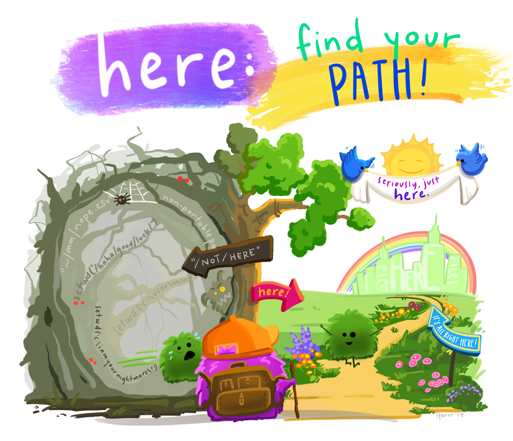

Figure 6: Illustration by [Allison Horst](https://github.com/allisonhorst)

## The problem with `setwd()`

> If the first line of your R script is

> `setwd("C:\Users\jenny\path\that\only\I\have")`

> I will come into your office and SET YOUR COMPUTER ON FIRE🔥.

— [Jenny Bryan](https://x.com/hadleywickham/status/940021008764846080)

- `setwd()` depends on your entire machine’s folder structure
- `setwd()` breaks when you
  - send your project folder to a collaborator
  - make your analyses open
  - change the location of your project folder
- using slashes is also dependent on your operating system

## The benefit of `here()`

- uses the top-level directory of your project as the working directory
- can separate folder names with a comma

**`here`**

Load the dataset using `here`

1. Install `here` (e.g., `install.packages("here")`)
2. Load `here` at the beginning of your package
   - or use `here::` before calling a function
3. Use the `here()` function to load in your data
4. Inspect the dataset however you usually would (e.g., `summary()`, `names()`, etc.)
5. Save your script

## `here::here()`

- install package

```
In the Console
```

```r
install.packages("here")
```

- load package and call the `here` function

```r
# load package
library(here)

# read in data
df_data <- read.csv(here("data", "data_lifetime_pilot.csv"))
```

- or directly call the `here` function without loading the package

```r
# read in data without loading here
df_data <- read.csv(here::here("data", "data_lifetime_pilot.csv"))
```

**Reproduce your analysis**

1. Make sure you save your script, then close your Rproject.
2. Re-open the project. Can you re-run the script?

# Learning objectives 🏁

Today we learned…

- learn about project-oriented workflows ✅
- create an RProject ✅
- establish a self-contained project environment with `here` ✅

# References

Bryan, J., Hester, J., Pileggi, S., & Aja, D. E. (n.d.). *What They Forgot to Teach You About R*. https://rstats.wtf/.

Bryan, J., & TAs, T. S. 545. (n.d.). *Chapter 2 R basics and workflows STAT 545*.

Müller, K. (2020). *Here: A simpler way to find your files*. https://CRAN.R-project.org/package=here

Using RStudio Projects. (2024). In *Posit Support*. https://support.posit.co/hc/en-us/articles/200526207-Using-RStudio-Projects.

Wickham, H., Çetinkaya-Rundel, M., & Grolemund, G. (2023). *R for Data Science* (2nd ed.).